# GE 461 Introduction to Data Science

Statistical Models by Savaş Dayanık

#### Week 5: Advertising and Promotion

The Dodgers is a professional baseball team and plays in the Major Baseball League. The team owns a 56,000-seat stadium and is interested in increasing the attendance of their fans during home games.*At the moment the team management would like to know if bobblehead promotions increase the attendance of the team’s fans?* This is a case study based on Miller (2014 Chapter 2).

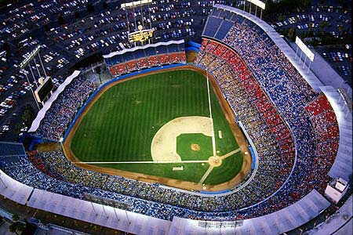

[figure not shown]

[figure not shown]

Figure 1: 56,000-seat Dodgers stadium (left), shirts and caps (middle), bobblehead (right)

```r
include_graphics(c("los_angeles-dodgers-stadium.jpg",
                 "Los-Angeles-Dodgers-Promo.jpg",
                 "adrian_bobble.jpg"))
```

The 2012 season data in the `events` table of SQLite database `data/dodgers.sqlite` contain for each of 81 home play the

- month,
- day,
- weekday,
- part of the day (day or night),
- attendance,
- opponent,
- temperature,
- whether cap or shirt or bobblehead promotions were run, and
- whether fireworks were present.

## Prerequisites

We will use `R`, `RStudio`, `R Markdown` for the next three weeks to fit statistical models to various data and analyze them. Read Wickham and Grolemund (2017) online

- [Section 1.1](https://r4ds.had.co.nz/introduction.html#prerequisites) for how to download and install `R` and `RStudio`,
- [Chapter 27](https://r4ds.had.co.nz/r-markdown.html) for how to use `R Markdown` to interact with `R` and conduct various predictive analyses.

All materials for the next three weeks will be available on [Google drive](https://drive.google.com/drive/folders/1ehZI2fF7awKOBik7YSuAbyGV7Sa2jOj_?usp=sharing).

## March 1: Exploratory data analysis

1. Connect to `data/dodgers.sqlite`. Read table `events` into a variable in `R`.
   - Read Baumer, Kaplan, and Horton (2017, Chapters 1, 4, 5, 15) ([Second edition online](https://mdsr-book.github.io/mdsr2e/)) for getting data from and writing them to various SQL databases.
   - Because we do not want to hassle with user permissions, we will use SQLite for practice. I recommend `PostgreSQL` for real projects.
   - Open `RStudio` terminal, connect to database `dodgers.sqlite` with `sqlite3`. Explore it (there is only one table, `events`, at this time) with commands
     - `.help`
     - `.databases`
     - `.tables`
     - `.schema <table_name>`
     - `.headers on`
     - `.mode column`
     - `SELECT ...`
     - `.quit`
   - Databases are great to store and retrieve large data, especially, when they are indexed with respect to variables/columns along with we do search and match extensively.
   - `R` (likewise, `Python`) allows one to seeminglessly read from and write to databases. For fast analysis, keep data in a database, index tables for fast retrieval, use `R` or `Python` to fit models to data.

```r
# Ctrl-shift-i
#library(RPostgreSQL)
library(RSQLite)  ## if package is not on the computer, then install it only once using Tools > Install packages...
con <- dbConnect(SQLite(), "../data/dodgers.sqlite") # read Modern Data Science with R for different ways to connect a database.

## dbListTables(con)

tbl(con, "events") %>%
  collect() %>%
  mutate(day_of_week = factor(day_of_week, levels = c("Monday", "Tuesday", "Wednesday", "Thursday", "Friday", "Saturday", "Sunday")),
         month = factor(month, levels = c("APR","MAY","JUN","JUL","AUG","SEP","OCT"))) %>%
  mutate_if(is.character, factor) %>%
  mutate(temp = round((temp- 32)*5/9)) -> events

# events %>% distinct(month)
# events$day_of_week %>% class()
# events$day_of_week %>% levels()
# events
# summary(events)
```

```r
events %>%
  count(bobblehead, fireworks)
```

```
## # A tibble: 3 x 3
##   bobblehead fireworks     n
##   <fct>      <fct>     <int>
## 1 NO         NO           56
## 2 NO         YES          14
## 3 YES        NO           11
```

2. What are the number of plays on each week day and in each month of a year?

```r
events %>%
  count(day_of_week, month) %>%
  pivot_wider(names_from = day_of_week, values_from = n) %>%
  pander(caption = "(\\#tab:monthweekday) Number of games played in each weekday and month")
```

Table 1: Number of games played in each weekday and month

| month | Monday | Tuesday | Wednesday | Thursday | Friday | Saturday | Sunday |
| --- | --- | --- | --- | --- | --- | --- | --- |
| APR | 1 | 2 | 2 | 1 | 2 | 2 | 2 |
| MAY | 3 | 3 | 2 | 1 | 3 | 3 | 3 |
| JUN | 1 | 1 | 1 | 1 | 2 | 2 | 1 |
| JUL | 3 | 3 | 2 | NA | 1 | 1 | 2 |
| AUG | 2 | 2 | 3 | 1 | 3 | 2 | 2 |
| SEP | 1 | 1 | 1 | 1 | 2 | 3 | 3 |
| OCT | 1 | 1 | 1 | NA | NA | NA | NA |

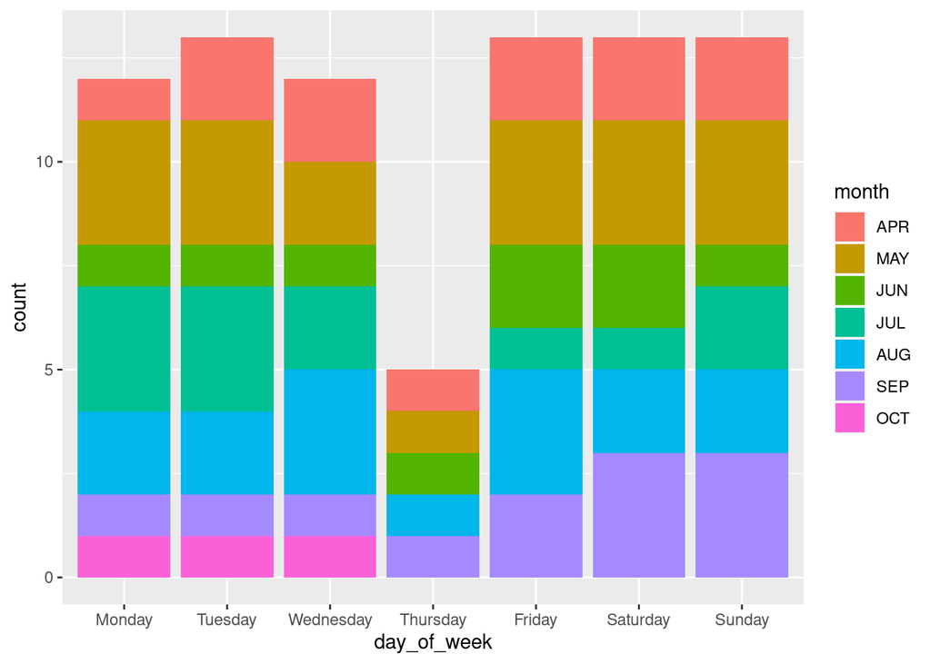

Figure 2: Barplot of counts of games for each weekday and month

```r
events %>%
  ggplot(aes(day_of_week)) +
  geom_bar(aes(fill=month))
```

Figure 3 shows your friend’s (very good) suggestion of headmap of total attendance versus weekday and month. The colors chabge from bright yellow to dark red as attendance increases. Default heatmap shuffles rows and columns so as to bring together weekdays and months with similar attendance. Here we see May, Aug, and Jul together within the months and Saturday, Friday, Sunday within the weekdays. Learn more about xtabs (cross-table) heatmap by typing `?xtabs` and `?heatmap` in the R console.

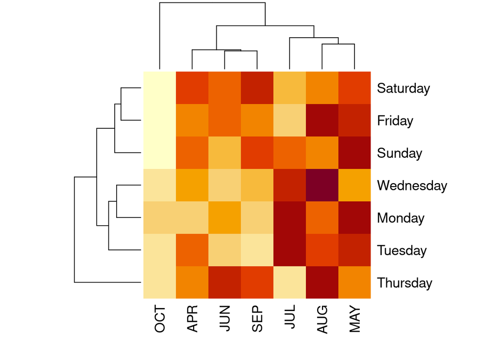

Figure 3: Heatmap of attendance versus weekday and month.

```r
xtabs(attend ~ day_of_week + month, events) %>%
  heatmap()
```

In Figure 4, I have added one more aes (colour) to capture day_night information. To avoid overplotting, I replaced `geom_point()` with `geom_jitter()`. These plots were also illuminating. So let us thank your friend who suggested this one, too.

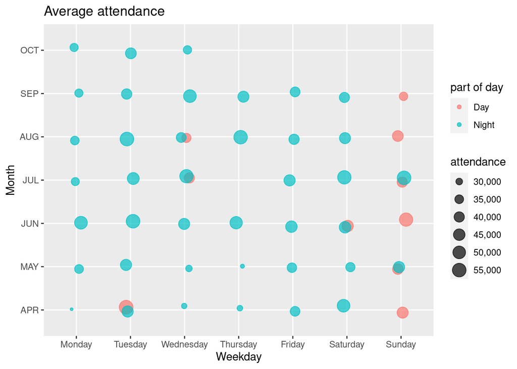

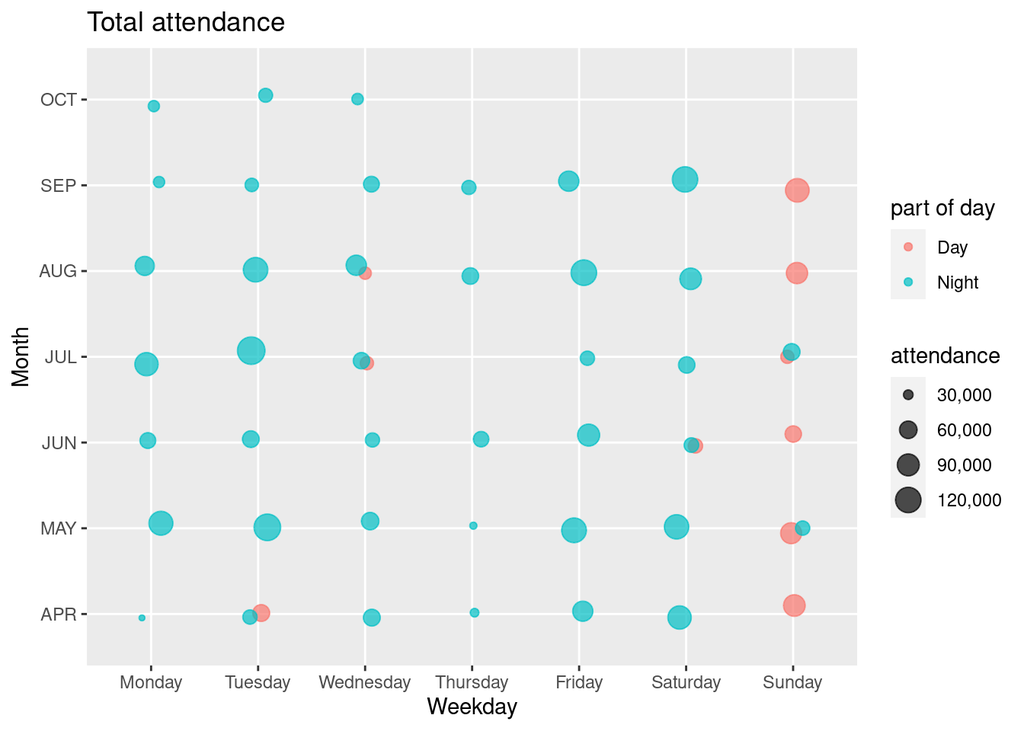

Figure 4: Average and total attendances on each weekday and month in each part of day

```r
sum_attend <- events %>%
  group_by(day_of_week, month, day_night) %>%
  summarize(mean_attend = mean(attend),
            total_attend = sum(attend), .groups = "drop")

sum_attend %>%
  ggplot(aes(day_of_week, month, month)) +
  geom_jitter(aes(size = mean_attend, col = day_night), width = .1, height = .1, alpha=0.7) +
  scale_size(labels = scales::comma) +
  labs(title = "Average attendance", size = "attendance", col = "part of day",
       x = "Weekday", y = "Month")

sum_attend %>%
  ggplot(aes(day_of_week, month)) +
  geom_jitter(aes(size = total_attend, col = day_night), width = .1, height = .1, alpha=0.7) +
  labs(title = "Total attendance", size = "attendance", col = "part of day",
       x = "Weekday", y = "Month") +
  scale_size(labels = scales::comma) +
  guides(col = guide_legend(order = 1),
         shape = guide_legend(order = 2))
```

3. Check the orders of the levels of the `day_of_week` and `month` factors. If necessary, put them in the logical order.

```r
levels(events$day_of_week)
```

```
## [1] "Monday"    "Tuesday"   "Wednesday" "Thursday"  "Friday"    "Saturday"
## [7] "Sunday"
```

```r
levels(events$month)
```

```
## [1] "APR" "MAY" "JUN" "JUL" "AUG" "SEP" "OCT"
```

4. How many times were bobblehead promotions run on each week day?

```r
events %>%
  count(day_of_week, bobblehead) %>%
  pivot_wider(names_from = bobblehead, values_from = n) %>%
  replace_na(list(YES = 0)) %>%
  mutate(Total = YES + NO) %>%
  select(-NO) %>%
  rename(Bobblehead = YES)
```

```
## # A tibble: 7 x 3
##   day_of_week Bobblehead Total
##   <fct>            <dbl> <dbl>
## 1 Monday               0    12
## 2 Tuesday              6    13
## 3 Wednesday            0    12
## 4 Thursday             2     5
## 5 Friday               0    13
## 6 Saturday             2    13
## 7 Sunday               1    13
```

5. How did the attendance vary across week days? Draw boxplots. On which day of week was the attendance the highest on average?

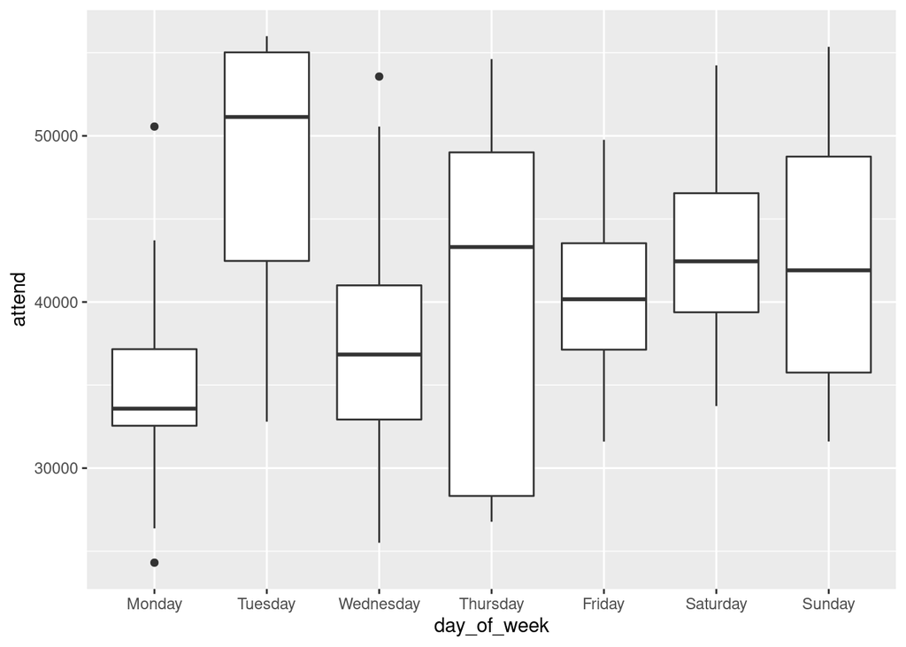

```r
events %>%
  ggplot(aes(day_of_week, attend)) +
  geom_boxplot()
```

```r
events %>%
  slice_max(order_by = attend, n=5)
```

```
## # A tibble: 5 x 12
##   month   day attend day_of_week opponent  temp skies day_night cap   shirt
##   <fct> <dbl>  <dbl> <fct>       <fct>    <dbl> <fct> <fct>     <fct> <fct>
## 1 APR      10  56000 Tuesday     Pirates     19 Clear Day       NO    NO
## 2 AUG      21  56000 Tuesday     Giants      24 Clear Night     NO    NO
## 3 JUL       1  55359 Sunday      Mets        24 Clear Night     NO    NO
## 4 JUN      12  55279 Tuesday     Angels      19 Clou… Night     NO    NO
## 5 AUG       7  55024 Tuesday     Rockies     27 Clear Night     NO    NO
## # … with 2 more variables: fireworks <fct>, bobblehead <fct>
```

6. Is there an association between attendance and
   - whether the game is played in day light or night?
   - Between attendance and whether skies are clear or cloudy?

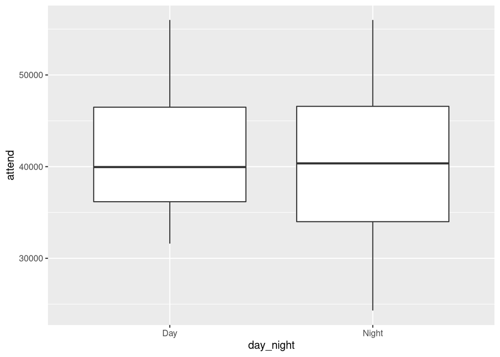

```r
events %>%
  ggplot(aes(day_night, attend)) +
  geom_boxplot()
```

```r
t.test(x=events$attend[events$day_night=="Day"],
       y=events$attend[events$day_night=="Night"])
```

```
##
##  Welch Two Sample t-test
##
## data:  events$attend[events$day_night == "Day"] and events$attend[events$day_night == "Night"]
## t = 0.42851, df = 23.62, p-value = 0.6722
## alternative hypothesis: true difference in means is not equal to 0
## 95 percent confidence interval:
##  -3531.652  5380.397
## sample estimates:
## mean of x mean of y
##  41793.27  40868.89
```

Since p-value (0.67) is large (greater than 0.05), we cannot reject null, which means there is no statistical difference between average attendance of games played in day and night.

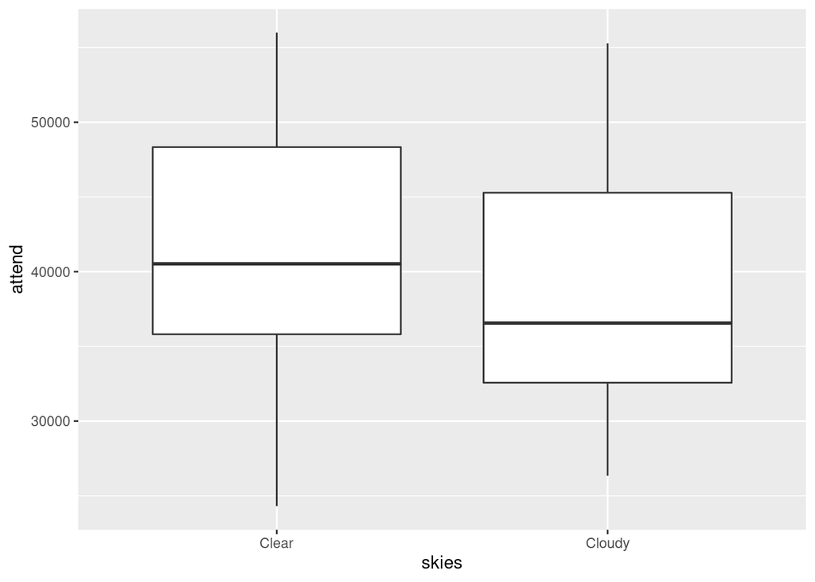

```r
events %>%
  ggplot(aes(skies, attend)) +
  geom_boxplot()
```

```r
t.test(x=events$attend[events$skies=="Clear"],
       y=events$attend[events$skies=="Cloudy"])
```

```
##
##  Welch Two Sample t-test
##
## data:  events$attend[events$skies == "Clear"] and events$attend[events$skies == "Cloudy"]
## t = 1.2868, df = 27.664, p-value = 0.2088
## alternative hypothesis: true difference in means is not equal to 0
## 95 percent confidence interval:
##  -1741.315  7617.103
## sample estimates:
## mean of x mean of y
##  41729.21  38791.32
```

We do not see a statisticall significant difference between the average attendance of the games played under clear and cloudy skies.

7. Is there an association between attendance and temperature?
   - If yes, is there a positive or negative association?
   - Do the associations differ on clear and cloud days or day or night times?

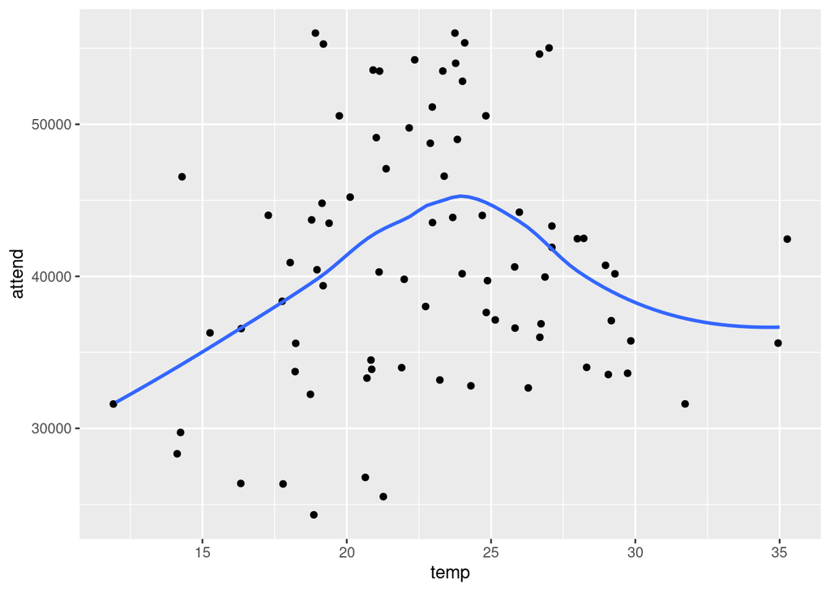

```r
events %>%
  ggplot(aes(temp, attend)) +
  geom_jitter() +
  geom_smooth(se = FALSE)
```

$$attend = \beta_0 + \beta_1 temp + \beta_2 (temp - 23)^+ + \varepsilon_i$$

```r
lm(attend ~ temp + pmax(0, temp - 23), data = events) %>% summary()
```

```
##
## Call:
## lm(formula = attend ~ temp + pmax(0, temp - 23), data = events)
##
## Residuals:
##      Min       1Q   Median       3Q      Max
## -17115.9  -5194.3    422.1   4789.0  15982.0
##
## Coefficients:
##                    Estimate Std. Error t value Pr(>|t|)
## (Intercept)         15253.3     7363.9   2.071 0.041631 *
## temp                 1303.4      360.2   3.618 0.000525 ***
## pmax(0, temp - 23)  -2240.1      612.7  -3.656 0.000463 ***
## ---
## Signif. codes:  0 '***' 0.001 '**' 0.01 '*' 0.05 '.' 0.1 ' ' 1
##
## Residual standard error: 7727 on 78 degrees of freedom
## Multiple R-squared:  0.1544, Adjusted R-squared:  0.1327
## F-statistic:  7.12 on 2 and 78 DF,  p-value: 0.001445
```

$$attend = \beta_0 + \beta_1 temp + \beta_2 (temp-23)^+ + \varepsilon_i$$

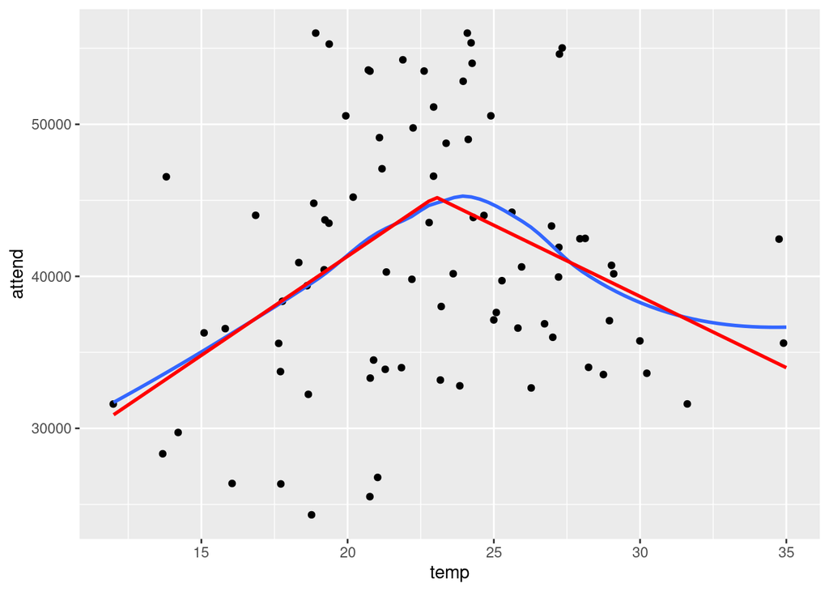

```r
events %>%
  ggplot(aes(temp, attend)) +
  geom_jitter() +
  geom_smooth(se = FALSE) +
  geom_smooth(se = FALSE, method = "lm",
              formula = y ~ x + pmax(x-23,0), col = "red")
```

There is statistically significant relation between attendance and temperature.

## Next time: A linear regression model

Regress attendance on `month`, `day of the week`, and `bobblehead` promotion.

```r
lmod1 <- lm(attend ~ month + day_of_week + bobblehead, data = events)
events$month %>% levels()
```

```
## [1] "APR" "MAY" "JUN" "JUL" "AUG" "SEP" "OCT"
```

```r
events2 <- events %>%
  mutate(month = relevel(month, "JUN"),
         day_of_week = relevel(day_of_week, "Sunday"))

lm(attend ~ month + day_of_week + bobblehead, data = events2) %>% summary()
```

```
##
## Call:
## lm(formula = attend ~ month + day_of_week + bobblehead, data = events2)
##
## Residuals:
##      Min       1Q   Median       3Q      Max
## -10786.5  -3628.1   -516.1   2230.2  14351.0
##
## Coefficients:
##                      Estimate Std. Error t value             Pr(>|t|)
## (Intercept)           47796.4     2671.9  17.889 < 0.0000000000000002 ***
## monthAPR              -7163.2     2732.7  -2.621             0.010830 *
## monthMAY              -9548.9     2526.9  -3.779             0.000337 ***
## monthJUL              -4313.4     2767.9  -1.558             0.123862
## monthAUG              -4785.3     2594.6  -1.844             0.069557 .
## monthSEP              -7134.2     2763.5  -2.582             0.012029 *
## monthOCT              -7825.9     4232.6  -1.849             0.068876 .
## day_of_weekMonday     -6724.0     2506.7  -2.682             0.009197 **
## day_of_weekTuesday     1187.5     2594.7   0.458             0.648672
## day_of_weekWednesday  -4264.0     2501.4  -1.705             0.092895 .
## day_of_weekThursday   -5948.6     3339.3  -1.781             0.079380 .
## day_of_weekFriday     -1840.2     2426.8  -0.758             0.450944
## day_of_weekSaturday    -351.9     2417.6  -0.146             0.884691
## bobbleheadYES         10714.9     2419.5   4.429            0.0000359 ***
## ---
## Signif. codes:  0 '***' 0.001 '**' 0.01 '*' 0.05 '.' 0.1 ' ' 1
##
## Residual standard error: 6120 on 67 degrees of freedom
## Multiple R-squared:  0.5444, Adjusted R-squared:  0.456
## F-statistic: 6.158 on 13 and 67 DF,  p-value: 0.0000002083
```

8. Is there any evidence for a relationship between attendance and other variables? Why or why not?

```r
lmod1 %>% summary()
```

```
##
## Call:
## lm(formula = attend ~ month + day_of_week + bobblehead, data = events)
##
## Residuals:
##      Min       1Q   Median       3Q      Max
## -10786.5  -3628.1   -516.1   2230.2  14351.0
##
## Coefficients:
##                      Estimate Std. Error t value             Pr(>|t|)
## (Intercept)          33909.16    2521.81  13.446 < 0.0000000000000002 ***
## monthMAY             -2385.62    2291.22  -1.041              0.30152
## monthJUN              7163.23    2732.72   2.621              0.01083 *
## monthJUL              2849.83    2578.60   1.105              0.27303
## monthAUG              2377.92    2402.91   0.990              0.32593
## monthSEP                29.03    2521.25   0.012              0.99085
## monthOCT              -662.67    4046.45  -0.164              0.87041
## day_of_weekTuesday    7911.49    2702.21   2.928              0.00466 **
## day_of_weekWednesday  2460.02    2514.03   0.979              0.33134
## day_of_weekThursday    775.36    3486.15   0.222              0.82467
## day_of_weekFriday     4883.82    2504.65   1.950              0.05537 .
## day_of_weekSaturday   6372.06    2552.08   2.497              0.01500 *
## day_of_weekSunday     6724.00    2506.72   2.682              0.00920 **
## bobbleheadYES        10714.90    2419.52   4.429            0.0000359 ***
## ---
## Signif. codes:  0 '***' 0.001 '**' 0.01 '*' 0.05 '.' 0.1 ' ' 1
##
## Residual standard error: 6120 on 67 degrees of freedom
## Multiple R-squared:  0.5444, Adjusted R-squared:  0.456
## F-statistic: 6.158 on 13 and 67 DF,  p-value: 0.0000002083
```

Check F-statistic’s p-value. If it is less than 0.05, then there is relation between attendance and predictors.

9. Does the `bobblehead` promotion have a statistically significant effect on the attendance?

Test $H_0: \beta_\text{BobbleheadYES} = 0$. Under $H_0$, t-stat in the summary has t-distribution with degrees of freedom equal to (number of samples - numbr of parameters estimated). We check directly p-value for the t-test. If p-value is small (< 0.05), then we reject the null hypothesis and conclude that BobbleHead is important in increasing the attendance in the games. Since p-value (0.0000359) is less than 5%, we reject the null. Therefore we conclude it is a good idea to use bobblehead to boos the number of fans coming to stadium to watch the game.

10. Do `month` and `day of week` variables help to explain the number of attendants?

Is there a relation between month and attendance (after we account for the effects of day_of_week and bobblehead)?

```r
# lmod2 <- lm(attend ~ skies, data = events)
# lmod2 %>% summary()
# lmod2 <- lm(attend ~month, data = events)
# lmod2 %>% summary()
small <- update(lmod1, . ~ . - month)
anova(small, lmod1)
```

```
## Analysis of Variance Table
##
## Model 1: attend ~ day_of_week + bobblehead
## Model 2: attend ~ month + day_of_week + bobblehead
##   Res.Df        RSS Df Sum of Sq      F  Pr(>F)
## 1     73 3129721926
## 2     67 2509574563  6 620147363 2.7594 0.01858 *
## ---
## Signif. codes:  0 '***' 0.001 '**' 0.01 '*' 0.05 '.' 0.1 ' ' 1
```

H_0: the small model is correct. If p-value is small (for example, less than 5%), as always we reject the null hypothesis (in this case, null says that the small model is correct). Here, p-value = 01858 < 5%, so it is small. We reject the small model. Therefore, we conclude that month and attendance are related (while day_of_week and bobbleheadYES are still in the model).

11. How many fans are expected to be drawn alone by a bobblehead promotion to a home game? Give a 90% confidence interval.
12. How good does the model fit to the data? Why? Comment on residual standard error and R$^2$. Plot observed attendance against predicted attendance.

Is day of week important? (Does day_of_week provide new explanation while the other predictors are still present in the model?)

```r
small <- update(lmod1, . ~ . - day_of_week)
anova(small, lmod1)
```

```
## Analysis of Variance Table
##
## Model 1: attend ~ month + bobblehead
## Model 2: attend ~ month + day_of_week + bobblehead
##   Res.Df        RSS Df Sum of Sq      F  Pr(>F)
## 1     73 3085413762
## 2     67 2509574563  6 575839199 2.5623 0.02704 *
## ---
## Signif. codes:  0 '***' 0.001 '**' 0.01 '*' 0.05 '.' 0.1 ' ' 1
```

We reject the small model because p-value (0.02704) is small (less than 0.05). SO conclude that day of week still contributes important information to pur understanding of attandance while the others two predcitors are in the model.

Variable selection

```r
smallest <- update(lmod1, . ~ . - day_of_week - month)
anova(smallest, small, lmod1)
```

```
## Analysis of Variance Table
##
## Model 1: attend ~ bobblehead
## Model 2: attend ~ month + bobblehead
## Model 3: attend ~ month + day_of_week + bobblehead
##   Res.Df        RSS Df Sum of Sq      F  Pr(>F)
## 1     79 3642937151
## 2     73 3085413762  6 557523389 2.4808 0.03157 *
## 3     67 2509574563  6 575839199 2.5623 0.02704 *
## ---
## Signif. codes:  0 '***' 0.001 '**' 0.01 '*' 0.05 '.' 0.1 ' ' 1
```

```r
small
```

```
##
## Call:
## lm(formula = attend ~ month + bobblehead, data = events)
##
## Coefficients:
##   (Intercept)       monthMAY       monthJUN       monthJUL       monthAUG
##       38519.6        -2603.6         6561.4         2147.8         1658.4
##      monthSEP       monthOCT  bobbleheadYES
##         435.4        -1816.0        12867.3
```

```r
small2 <- update(lmod1, . ~ . - month)
anova(smallest, small2, lmod1)
```

```
## Analysis of Variance Table
##
## Model 1: attend ~ bobblehead
## Model 2: attend ~ day_of_week + bobblehead
## Model 3: attend ~ month + day_of_week + bobblehead
##   Res.Df        RSS Df Sum of Sq      F  Pr(>F)
## 1     79 3642937151
## 2     73 3129721926  6 513215226 2.2836 0.04583 *
## 3     67 2509574563  6 620147363 2.7594 0.01858 *
## ---
## Signif. codes:  0 '***' 0.001 '**' 0.01 '*' 0.05 '.' 0.1 ' ' 1
```

```r
anova(smallest, lmod1)
```

```
## Analysis of Variance Table
##
## Model 1: attend ~ bobblehead
## Model 2: attend ~ month + day_of_week + bobblehead
##   Res.Df        RSS Df  Sum of Sq      F   Pr(>F)
## 1     79 3642937151
## 2     67 2509574563 12 1133362588 2.5215 0.008408 **
## ---
## Signif. codes:  0 '***' 0.001 '**' 0.01 '*' 0.05 '.' 0.1 ' ' 1
```

- It is wise to compare all nested models pairwise with anova()
- If p-value is slightly above 5%, we may call anova to be inconclusive. Use cross-validation to decide between two models:
  - For cross-validation:
    - Split the data into folds (say 10 for large data, 5 or small for small data; here I would have taken 5)
    - For each of five folds
      - Remove the test fold
      - Train all models that you want to compare on the remaining four folds combined.
      - Test all models on the held-out fold
        - Calculate MSE, MAE
    - Take average of performance measures (MSE, MAE) across all ftest folds.
    - Pick the model which has the most favorable performance measures.
13. Predict the number of attendees to a typical home game on a Wednesday in June if a bobblehead promotion is extended. Give a 90% prediction interval.

We will use the full model because anova analysis showed that all predictors were important

```r
predict(lmod1,
        newdata = data.frame(
          month = "JUN",
          day_of_week = "Wednesday",
          bobblehead = "YES"),
          interval = "prediction",
        level = 0.90)
```

```
##        fit     lwr      upr
## 1 54247.32 42491.1 66003.55
```

## Project (will be graded)

Include **all variables** and conduct a full regression analysis of the problem. Submit your `R markdown` and `html` files to course homepage on moodle.

- The project will be due 19:00 on Saturday, April 9, 2022.
- You can form groups with at most three members. Submit one report for the whole group.
- Submit Rmd and html in a single zip named with student ids of group members to Moodle page. There will soon be a link on the Moodle page. Do not forget to write names of group members, student ids inside Rmd.

## Bibliography

Baumer, B. S., D. T. Kaplan, and N. J. Horton. 2017. *Modern Data Science with R*. Chapman & Hall/CRC Texts in Statistical Science. CRC Press. https://books.google.com.tr/books?id=NrddDgAAQBAJ.

Miller, T. W. 2014. *Modeling Techniques in Predictive Analytics with Python and R: A Guide to Data Science*. FT Press Analytics. Pearson Education. https://books.google.com.tr/books?id=PU6nBAAAQBAJ.

Wickham, H., and G. Grolemund. 2017. *R for Data Science*. O’Reilly Media. https://books.google.com.tr/books?id=aZRYrgEACAAJ.